# White Wine Data Investigation

I added a new feature: Bound Sulfur Dioxide. Here I am going to check how it affects the quality of wines.

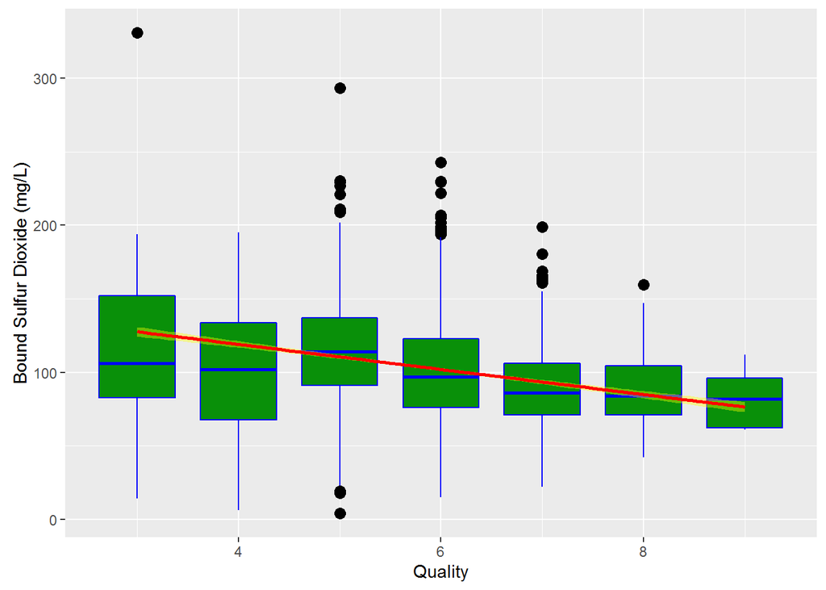

I am afraid that the outliers of Bound Sulfur Dioxide are affecting the accuracy. I need to remove these outliers.

Redraw the plot.

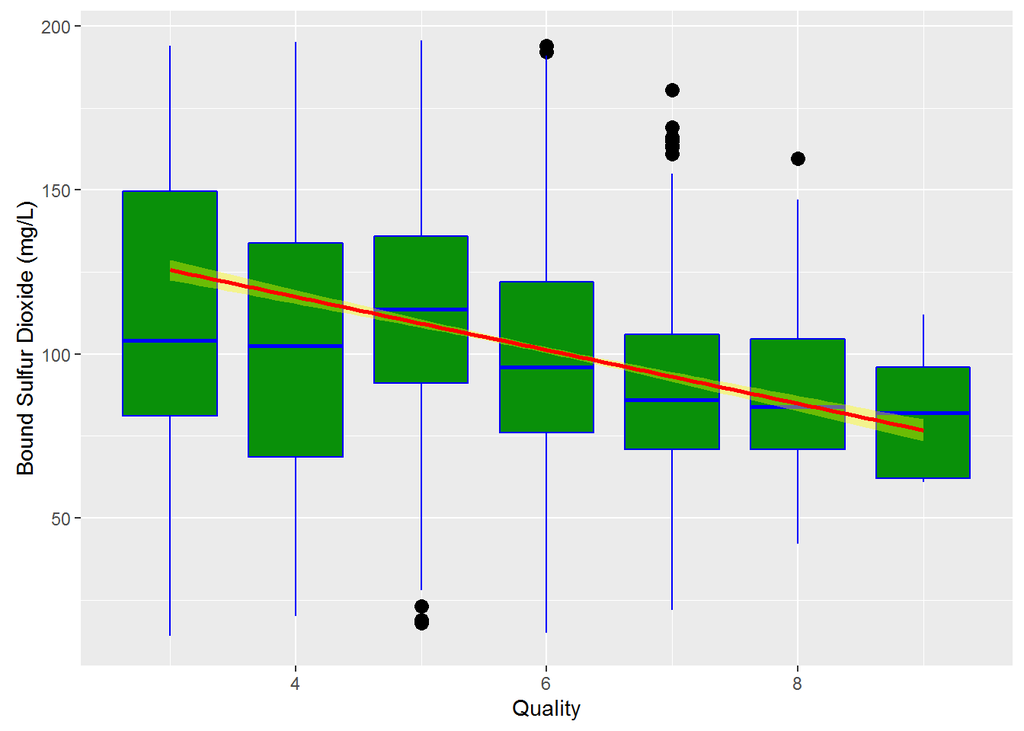

From the line modeling in the plot above, we can see that wines with higher Bound Sulfur Dioxide tend to have low quality.

Here let us look at Chlorides and the quality of wines

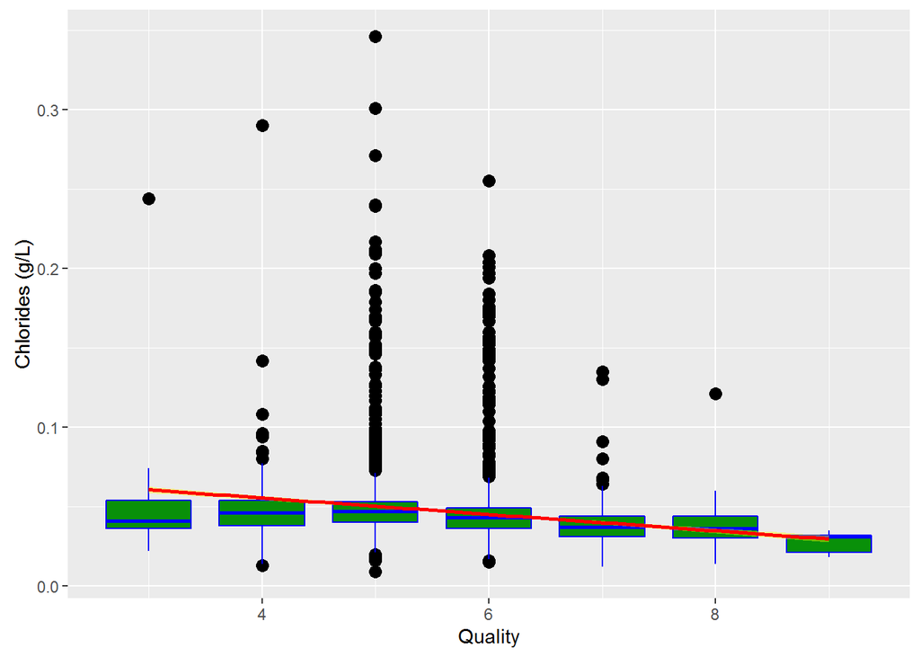

I am afraid that the outliers of Chlorides are affecting the accuracy. I need to remove these outliers.

Redraw the plot.

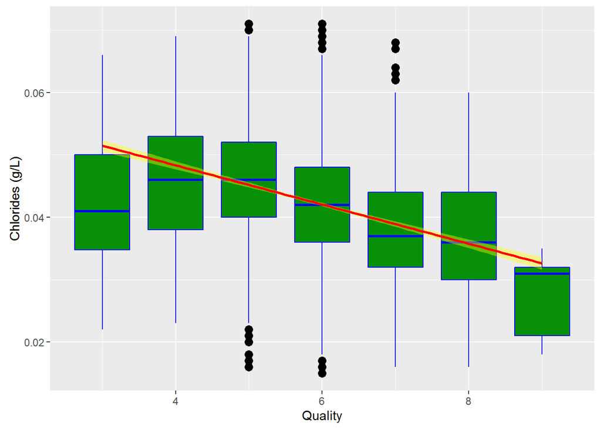

The line modeling in the plot above shows that wines with higher chlorides tend to have low quality.

Here let us look at Sulphates and the quality of wines.

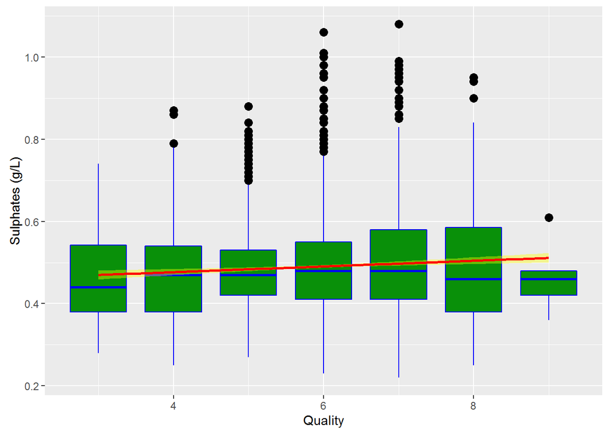

It appears that wines with higher quality tend to have a bit higher Sulphates. However there are some outliers. Let us remove them and check it again.

Redraw the plot.

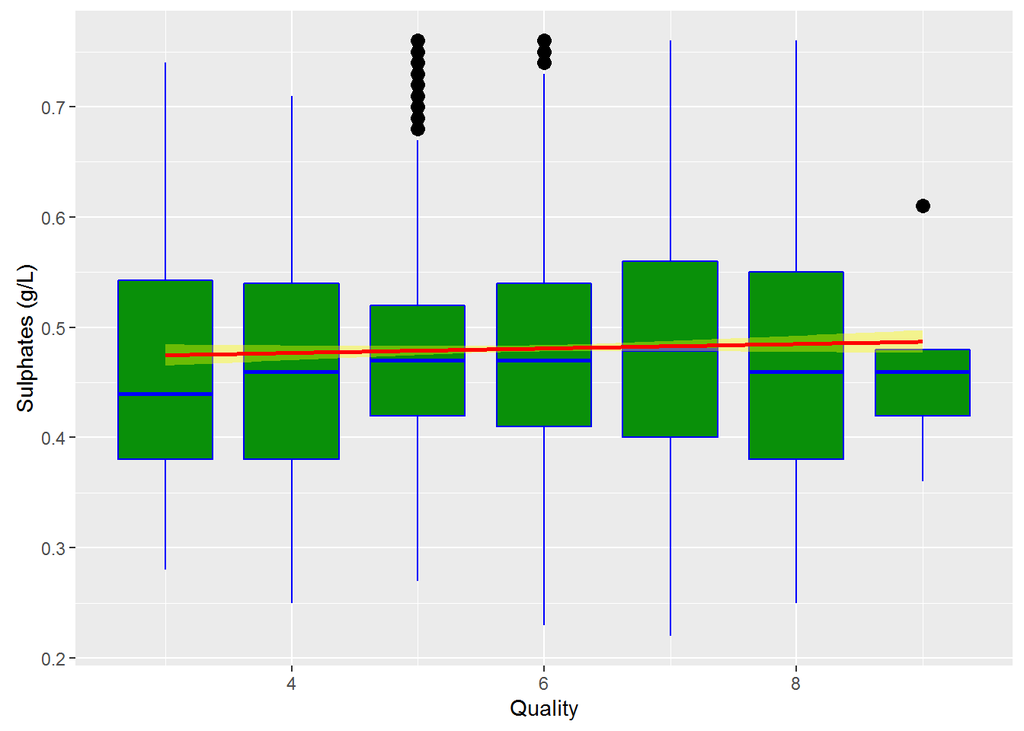

Now we can see that the line modeling does not show a clear relation between Quality and Sulphates.

Here let us look at pH and the quality of wines

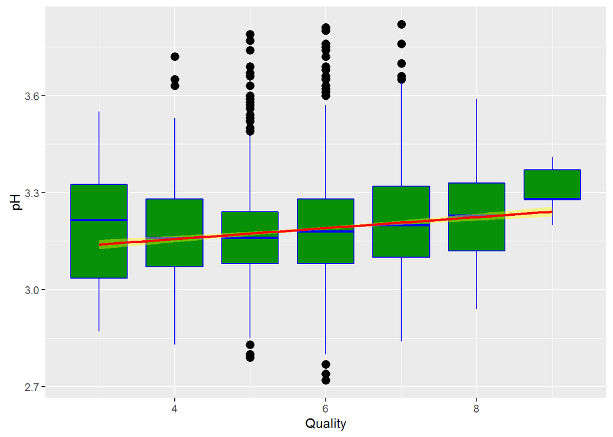

It appears that wines with higher quality tend to have a bit higher pH, i.e. less acid. Let us remove the outliers and check it again.

Redraw the plot.

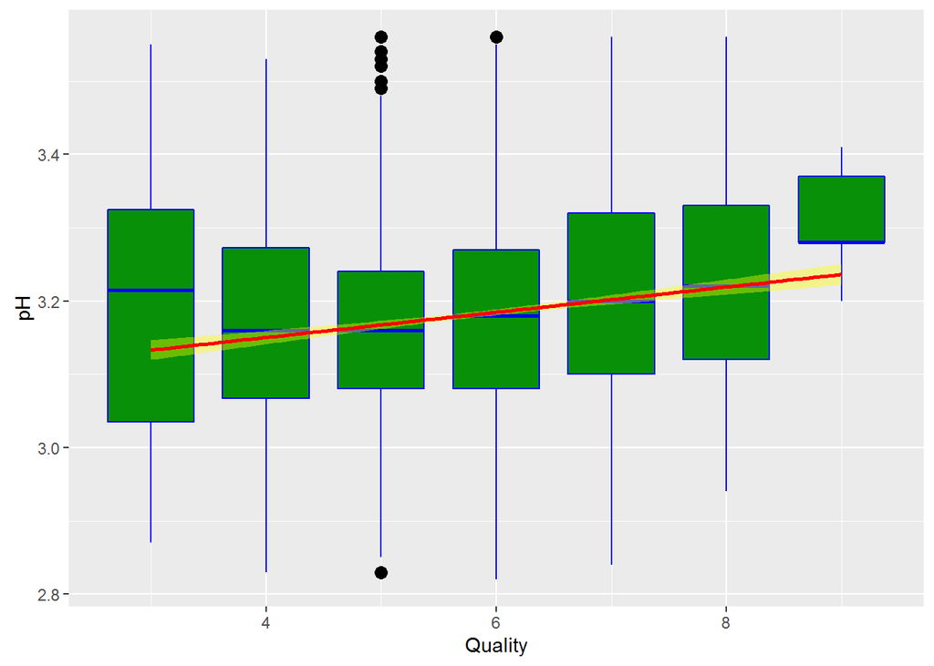

Now we can see the line modeling is showing a correlation between pH and Quality. Higher pH does bring higer Quality.

Since pH is affected by Fixed Acidity, Volatile Acidity and Citric Acid, I predict that wine with higher quality should have less acids.

Here I will study the Fixed Acidity.

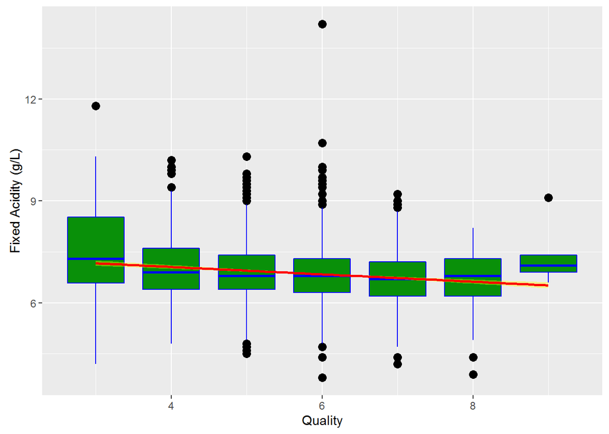

There exist some outliers of Fixed Acidity which are affecting the accuracy. I need to remove these outliers.

And redraw the plot

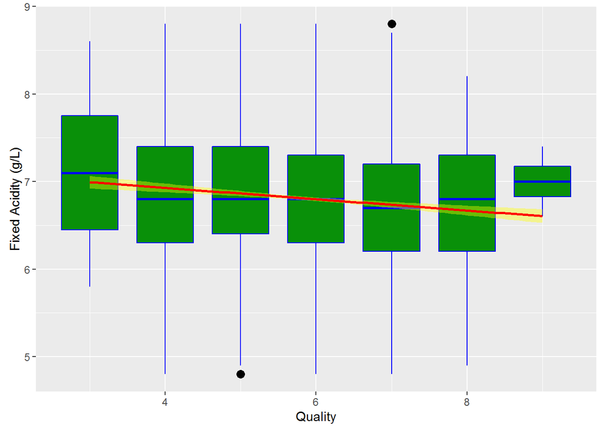

In the plot above, the line modeling shows Fixed Acidity correlates with Quality negatively and weakly. Wines with higher Fixed Acidity tend to have a bit low quality.

How about Volatile Acidity?

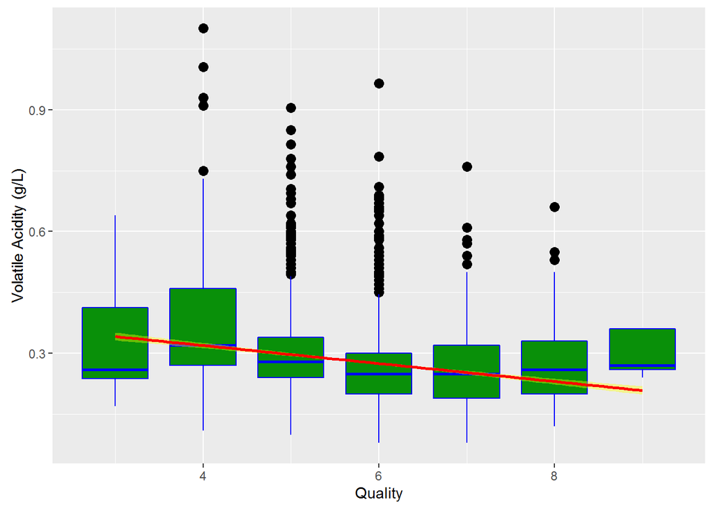

There exist some outliers of Volatile Acidity which are affecting the accuracy. I need to remove these outliers.

And redraw the plot

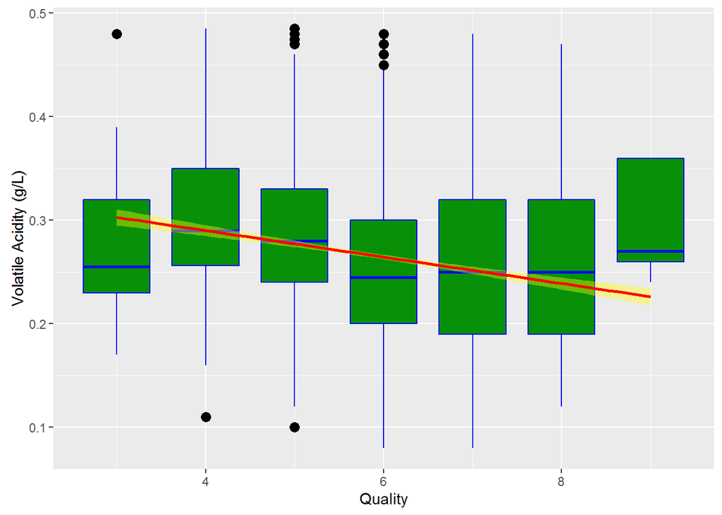

The line modeling in the plot above shows that the volatile acidity correlates with the quality of wines negatively and very weakly. Wines with higher Volatile Acidity tend to have a bit low quality.

Here I add a new variable. It is the total acidity, which is the sum of the fixed acidity and the volatile acidity. I am going to investigate how it affects the quality of wines.

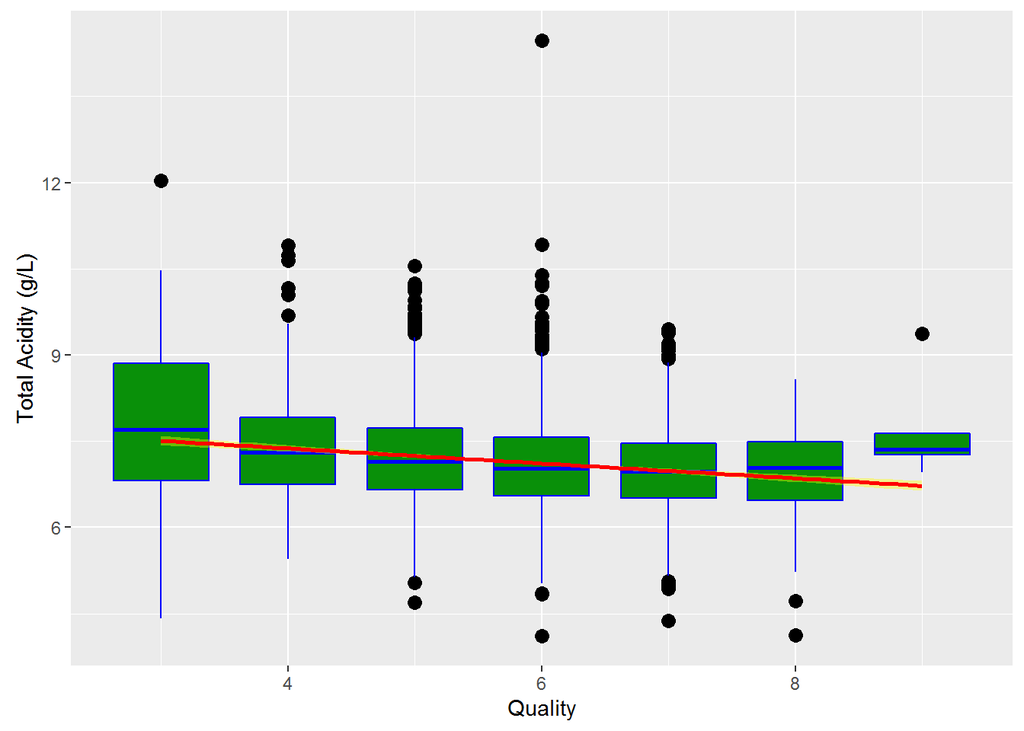

There exist some outliers of Total Acidity which are affecting the accuracy. I need to remove these outliers.

And redraw the plot

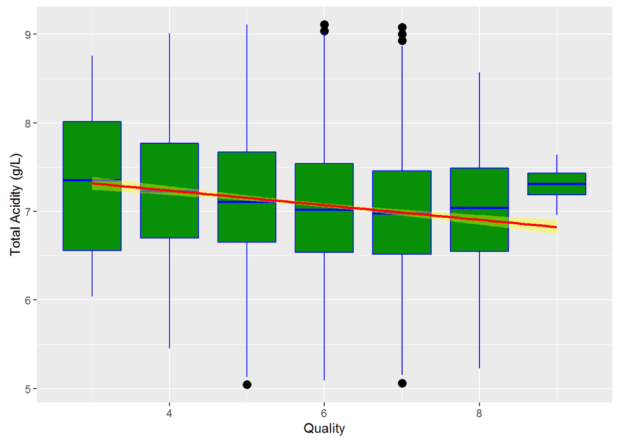

The line modeling in the plot above shows that the total acidity affects the quality of wines a bit. The wines with high Total Acidity tend to have a bit low Quality.

To further study it, I am going to create the Density Distribution plot.

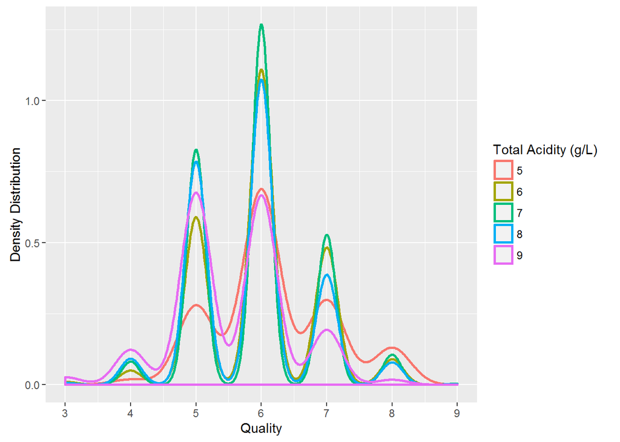

In this plot, we can see that when Total Acidity is 5g/L, we have more wines with high Quality, such as Quality = 8. With Total Acidity increasing, the number of wines with high quality (=8) decreases.

Next, let us have a look at Citric Acid.

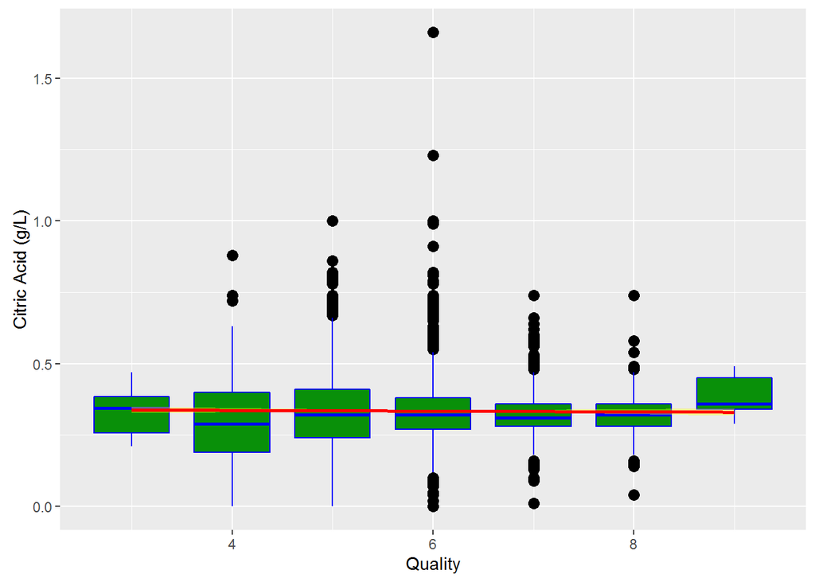

There exist some outliers of Citric Acid which are affecting the accuracy. I need to remove these outliers.

And redraw the plot

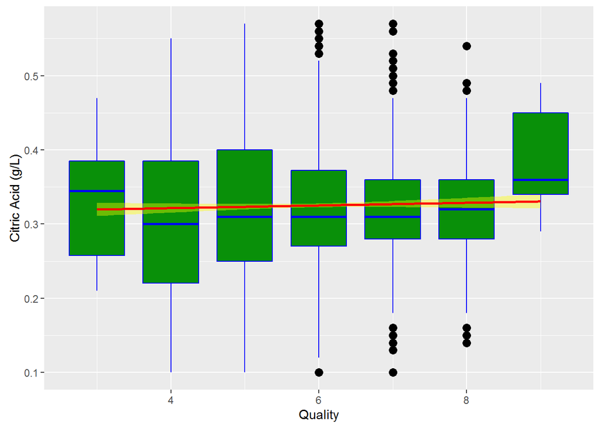

The line modeling is almost flat in the plot above. It shows that the citric acid does not affect the quality of wines.

It is said that salt is added to wine with high acidity, in order to soften the acidity in wine. Here I am going to study the relation between Chlorides and the Acidities.

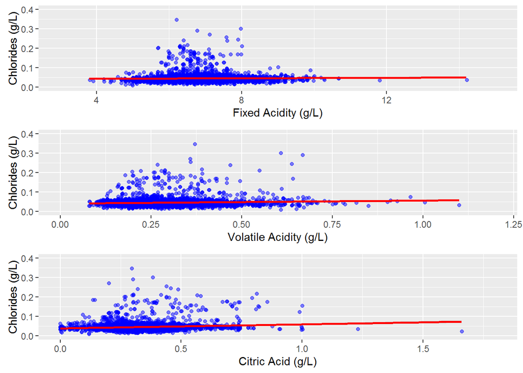

We can see that there exists some kind of positive correlation between acidity and salt. But we need to remove the outliers to further verify it.

Let us draw the plots again.

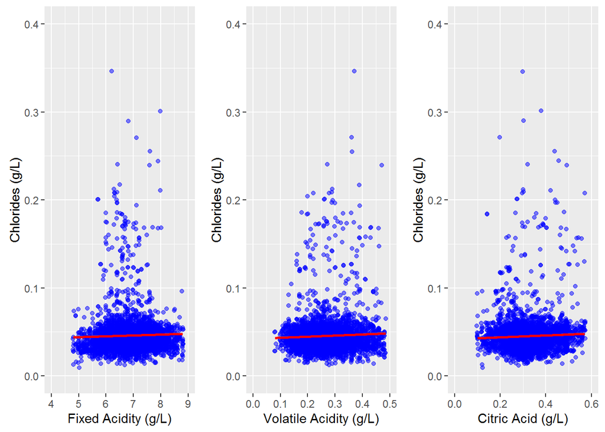

In the three plot above, the line modeling is almost flat. It means that the relation between Fixed Acidity/Volatile Acidity/Citric Acid and Chlorides are not clear. It does not appear that wine with more salt also has higher acids. So it does not show that salt is added into wine with high citric acid.

Study shows that fermentation in wine is just like that in bread. The yeast is added into wine. The yeast eats the sugar in grape. When this happens, the wine has very little residual sugar and higher alcohol levels. Here let us check if this is true.

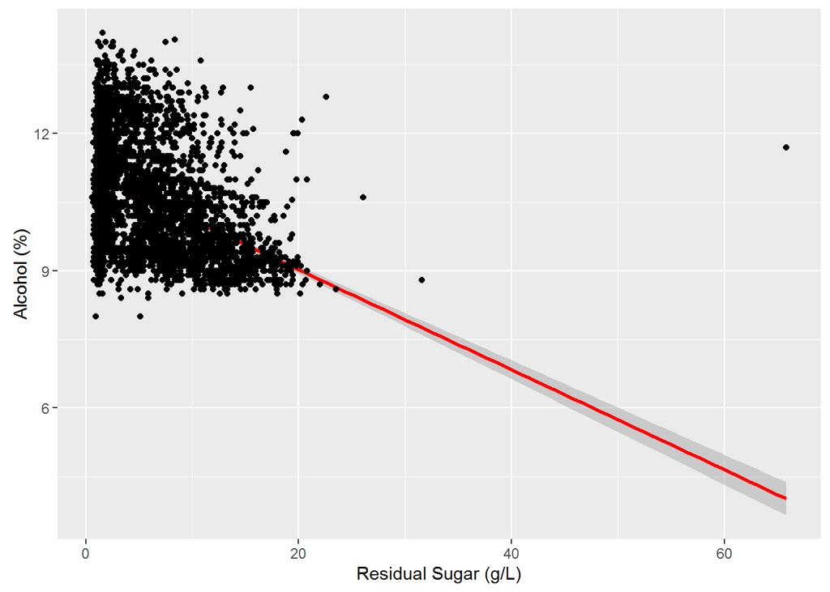

Here I will remove the outliers of Residual Sugar, in order to get an accurate result.

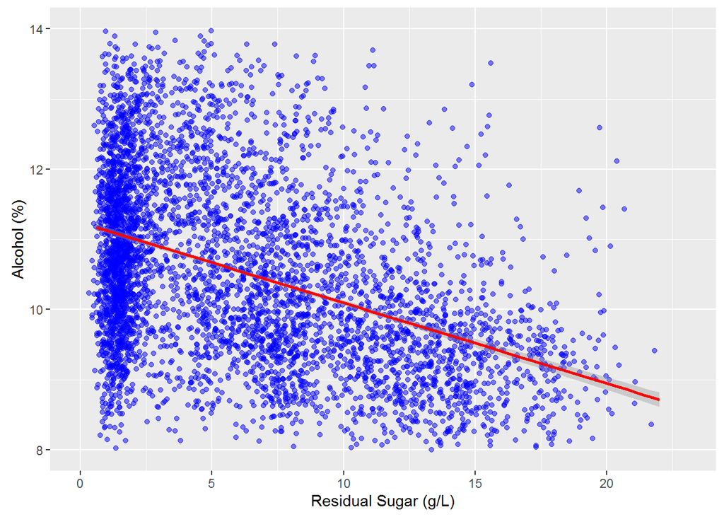

Acid brings the taste of dry. It reduces the sweetness of the wine. I wonder if there is any relation between Citric Acid/Fixed Acidity/Volatile Acidity and Residual Sugar in high quality wines. Here I will study the new variable Total Acidity’s correlation with Residual Sugar.

So let get the data set which has quality >= 6.

And then we remove the outliers of Total Acidity and Residual Sugar.

Draw the plot of Total Acidity and Residual Sugar.

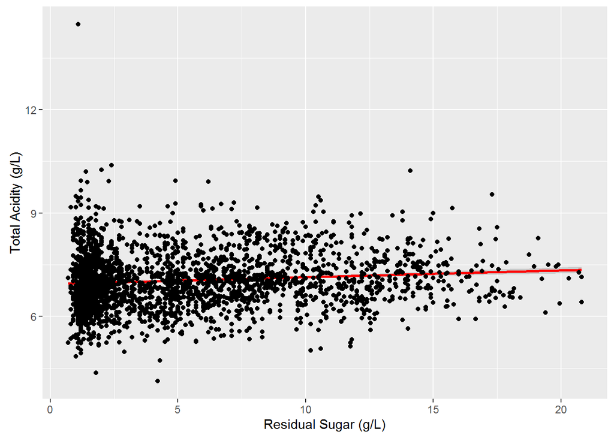

The line modeling in the plot above is almost flat. It does not show a clear correlation between Residual Sugar and Total Acidity. We cannot see that high quality wines tends to have high Total Acidity if its Residual Sugar level is also high.

Acids in wines decrease the pH value. The following plot shows the relationship between the new variable Total Acidity and pH values.

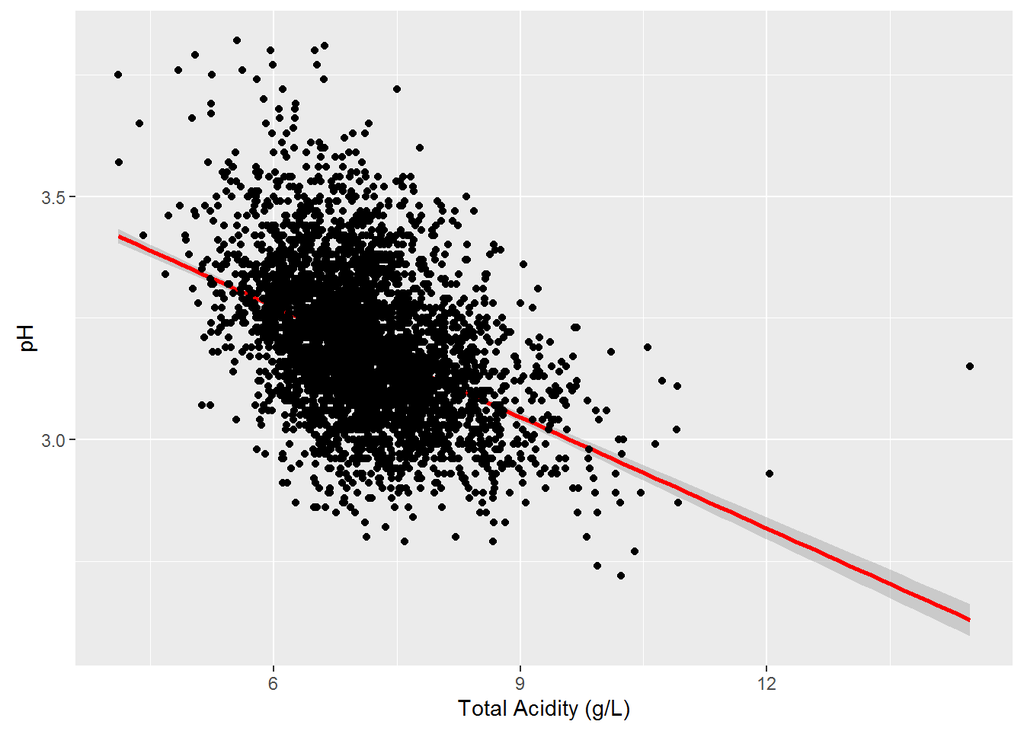

Remove the outliers on Fixed Acidity which may affect the accuracy.

Redraw the plot.

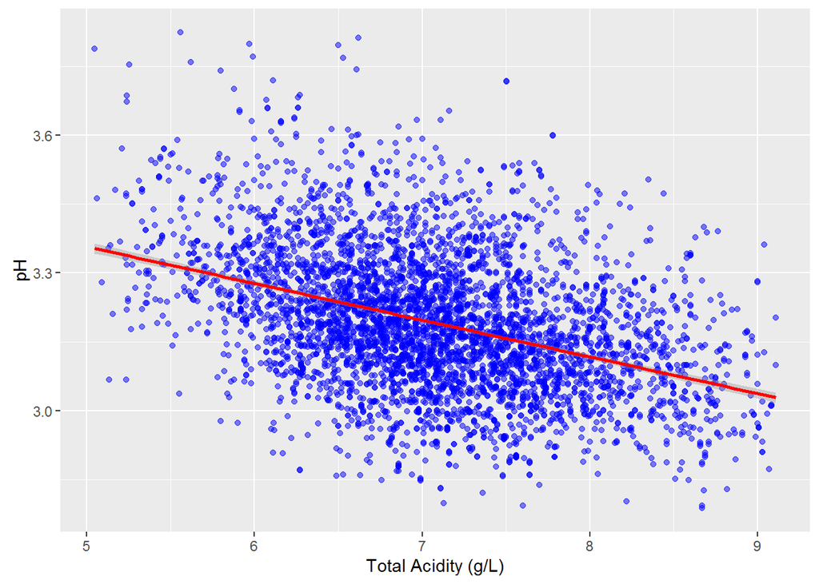

In the plot above, the line modeling shows a clear negative correlation between pH and Total Acidity. This indicates that high Total Acidity causes the lower pH value. This verifies the relationship between acids and pH value in wines mathematically.

# Bivariate Analysis

## Talk about some of the relationships you observed in this part of the investigation. How did the feature(s) of interest vary with other features in the dataset?

Alcohol and Density correlates strongly with Quality. The higher Alcohol level in the wine, the better quality. However this conclusion is reached only when the alcohol level is from 11% to 13%. If the alcohol level goes beyond the range, we do not know whether it still brings high quality of wine. The higher Density in the wine, the lower quality. However the residual sugar makes the most contribution to the density. And study shows that higher Residual Sugar in wines brings down the quality.

Some of other features also correlate with Quality. But only weakly. Others show no clear correlation at all. - We can see that wines with higher Total Sulfur Dioxide tends to have low quality. - We can see that Free Sulfur Dioxide in wines does not seem to correlate with Quality. - We can see that wines with higher Bound Sulfur Dioxide tends to have low quality. - We can see that wines with higher chlorides tends to have low quality. - It appears that wines with higher Sulphates tend to have a bit higher Quality. - It appears that wines with higher pH tend to have a bit higher quality. - It appears that the fixed acidity correlates negatively with the quality of wines very weakly. Wines with higher Fixed Acidity tend to have a bit low quality. - It appears that the volatile acidity correlates negatively with the quality of wines very weakly. Wines with higher Volatile Acidity tend to have a bit low quality. - It appears that the total acidity affects negatively the quality of wines a bit. The wines with high Total Acidity tend to have a bit low Quality. - It appears that the citric acid does not seem to affect the quality of wines.

## Did you observe any interesting relationships between the other features (not the main feature(s) of interest)?

- It is said that salt is added to wine with high acidity, in order to soften the acidity in wine. But study does not show clearly that Chlorides has a correlation with Acids.
- Fermentation in wine is just like that in bread. The yeast is added into wine. It eats the sugar in grapes and converts it to alcohol. Study verifies that the wine with higher Residual Sugar appears to have less alcohol level.
- Acid brings the taste of dry, which reduces the sweetness of the wine. However study shows that in higher (>=6) quality wines, high acids does not seem to have high Residual Sugar in wines.
- Study indicates that high Total Acidity causes the lower pH value. This verifies the relationship between acids and pH value in wines mathematically.

## What was the strongest relationship you found?

Wines with high alcohol level tend to have high quality.

# Multivariate Plots Section

Here we study the collective effect by Alcohol and Residual Sugar on Quality of wines.

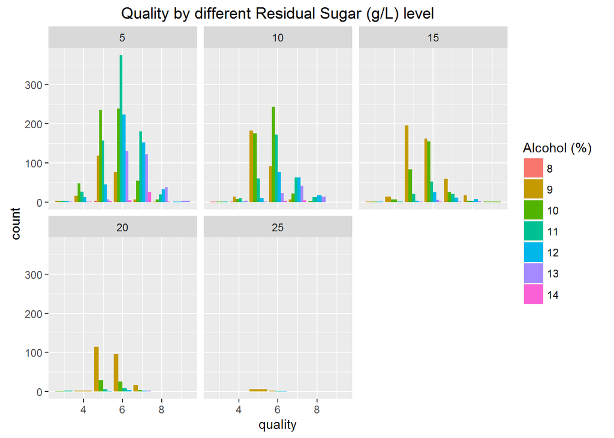

And these plots above are redrawn by switching the two parameters.

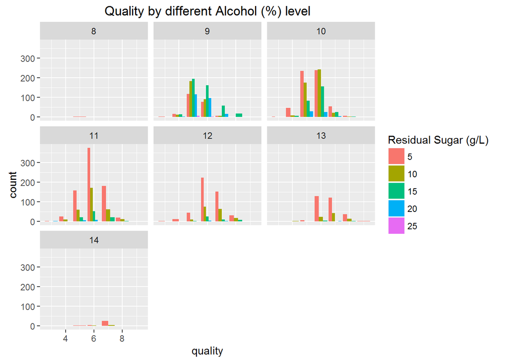

Now let us look at Chlorides and Total Acidity. I would like to find how these two variables combine to affect Quality of wines.

At first, need to remove outliers of Total Acidity from the dataset.

Secondly, need to remove outliers of Chlorides from the dataset.

Then convert the continuous variable Chlorides to be categorical.

Then convert the continuous variable total.acidity to be categorical.

Here are the plots showing the collective effects on Quality by Chlorides and Total Acidity.

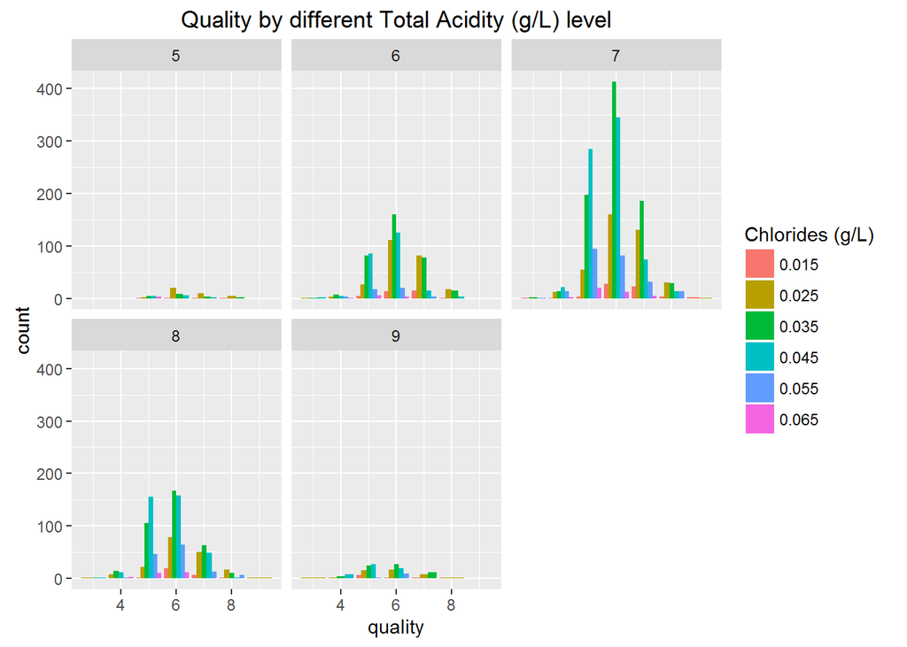

Here the plots are redrawn by switching the two parameters.

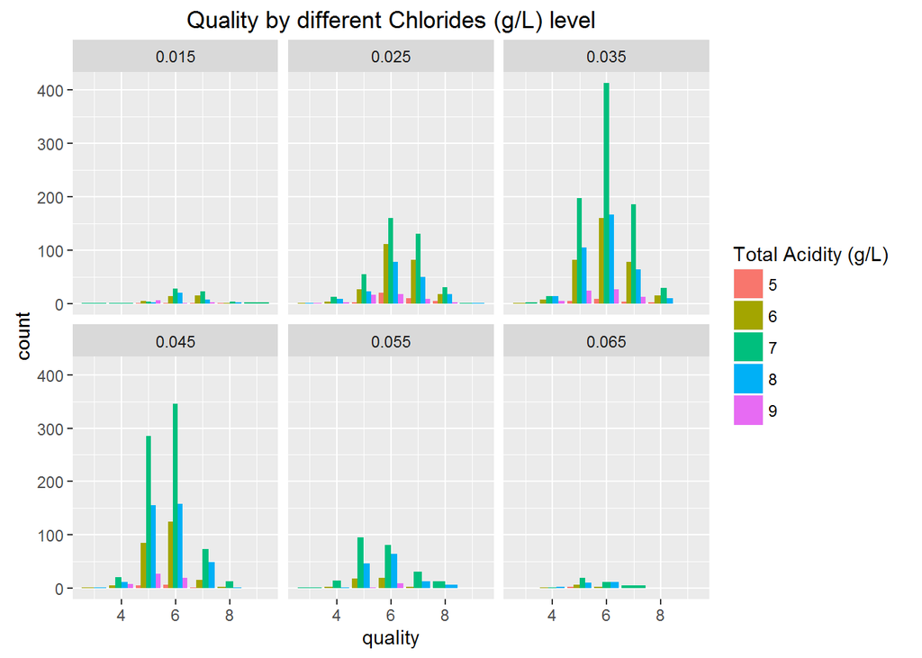

In the plots above, we can see that when Total Acidity is about 7g/L, we have maximum number of wines with high Quality. And when Chlorides is about 0.025 g/L to 0.035g/L, we have the more wines with high Quality.

Now let us have a loot at residual.sugar and acidity. The balance supports vivacity.

Then convert the continuous variable Residual Sugar to be categorical.

Then convert the continuous variable total.acidity to be categorical.

Here are the plots showing the collective effects on Quality by Total Acidity and Residual Sugar.

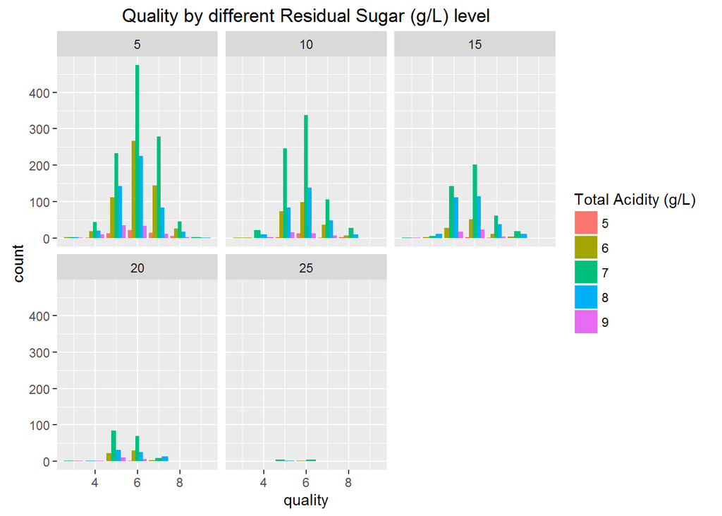

Here those plots are redrawn by switching the two parameters.

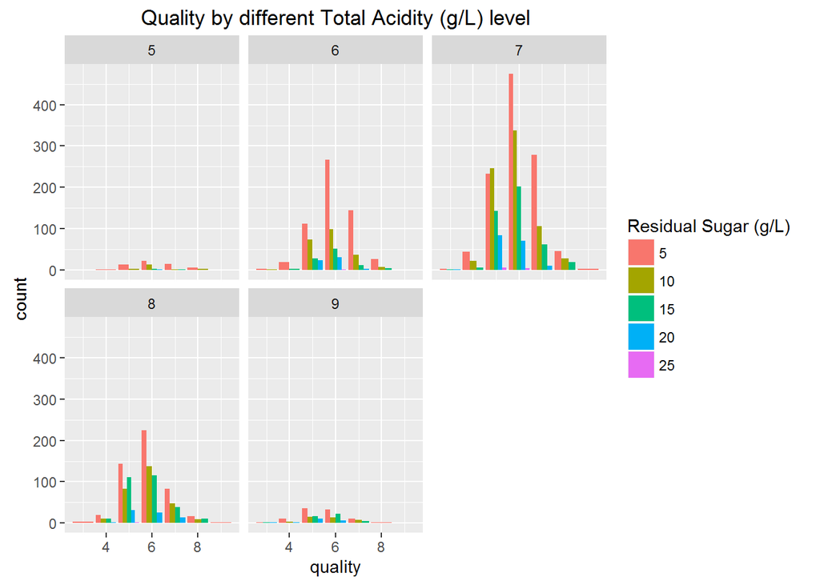

In the plots above, we can see that when Total Acidity is 7g/L and Residual Sugar is 5g/L, we have the maximum number of wine with high Quality.

All these plots suggest that we can build a linear model and use those variables in the linear model to predict the quality of a white wine.

```
##
## Calls:
## m1: lm(formula = quality ~ alcohol + residual.sugar, data = wine_no_outlier)
## m2: lm(formula = quality ~ alcohol + residual.sugar + density, data = wine_no_outlier)
## m3: lm(formula = quality ~ alcohol + residual.sugar + density + fixed.acidity,
##     data = wine_no_outlier)
## m4: lm(formula = quality ~ alcohol + residual.sugar + density + fixed.acidity +
##     volatile.acidity, data = wine_no_outlier)
## m5: lm(formula = quality ~ alcohol + residual.sugar + density + fixed.acidity +
##     volatile.acidity + citric.acid, data = wine_no_outlier)
## m6: lm(formula = quality ~ alcohol + residual.sugar + density + fixed.acidity +
##     volatile.acidity + citric.acid + chlorides, data = wine_no_outlier)
## m7: lm(formula = quality ~ alcohol + residual.sugar + density + fixed.acidity +
##     volatile.acidity + citric.acid + chlorides + free.sulfur.dioxide,
##     data = wine_no_outlier)
## m8: lm(formula = quality ~ alcohol + residual.sugar + density + fixed.acidity +
##     volatile.acidity + citric.acid + chlorides + free.sulfur.dioxide +
##     total.sulfur.dioxide, data = wine_no_outlier)
## m9: lm(formula = quality ~ alcohol + residual.sugar + density + fixed.acidity +
##     volatile.acidity + citric.acid + chlorides + free.sulfur.dioxide +
##     total.sulfur.dioxide + pH, data = wine_no_outlier)
## m10: lm(formula = quality ~ alcohol + residual.sugar + density + fixed.acidity +
##     volatile.acidity + citric.acid + chlorides + free.sulfur.dioxide +
##     total.sulfur.dioxide + pH + sulphates, data = wine_no_outlier)
##
## =================================================================================================================================================
##                            m1          m2          m3          m4          m5          m6          m7          m8          m9           m10
## -------------------------------------------------------------------------------------------------------------------------------------------------
##   (Intercept)            2.131***   76.367***   63.774***   48.634**    49.474**    38.175*     39.142*     40.291*     149.732***   196.399***
##                         (0.133)    (15.582)    (18.733)    (18.380)    (18.461)    (18.839)    (18.726)    (19.590)     (26.094)     (27.111)
##   alcohol                0.346***    0.251***    0.265***    0.311***    0.310***    0.305***    0.311***    0.310***     0.180***     0.130***
##                         (0.012)     (0.023)     (0.026)     (0.026)     (0.026)     (0.026)     (0.026)     (0.026)      (0.033)      (0.034)
##   residual.sugar         0.024***    0.048***    0.044***    0.045***    0.045***    0.041***    0.036***    0.036***     0.078***     0.097***
##                         (0.003)     (0.006)     (0.007)     (0.007)     (0.007)     (0.007)     (0.007)     (0.007)      (0.010)      (0.010)
##   density                          -73.838***  -61.147**   -45.769*    -46.617*    -34.958     -36.235     -37.394     -149.877***  -197.318***
##                                    (15.497)    (18.708)    (18.358)    (18.439)    (18.844)    (18.731)    (19.608)     (26.430)     (27.468)
##   fixed.acidity                                 -0.022      -0.033      -0.035      -0.040*     -0.026      -0.026        0.087***     0.123***
##                                                 (0.018)     (0.018)     (0.018)     (0.018)     (0.018)     (0.018)      (0.025)      (0.026)
##   volatile.acidity                                          -2.111***   -2.101***   -2.086***   -2.019***   -2.028***    -1.951***    -1.924***
##                                                             (0.160)     (0.161)     (0.161)     (0.161)     (0.166)      (0.166)      (0.165)
```

[output cut: 9 more lines]

```
##                                                                                                                          (0.128)      (0.129)
##   sulphates                                                                                                                            0.767***
##                                                                                                                                       (0.127)
## -------------------------------------------------------------------------------------------------------------------------------------------------
##   R-squared                  0.2        0.2         0.2         0.2         0.2         0.2         0.2         0.2          0.2          0.3
##   adj. R-squared             0.2        0.2         0.2         0.2         0.2         0.2         0.2         0.2          0.2          0.3
##   sigma                      0.8        0.8         0.8         0.8         0.8         0.8         0.8         0.8          0.8          0.7
##   F                        473.2      324.7       243.9       238.3       198.6       171.8       158.4       140.8        131.9        124.3
##   p                          0.0        0.0         0.0         0.0         0.0         0.0         0.0         0.0          0.0          0.0
##   Log-likelihood         -4735.9    -4724.6     -4723.9     -4638.5     -4638.4     -4634.1     -4609.0     -4609.0      -4589.1      -4571.0
##   Deviance                2455.3     2441.6      2440.8      2340.1      2339.9      2335.0      2306.3      2306.2       2283.7       2263.4
##   AIC                     9479.9     9459.2      9459.8      9291.0      9292.8      9286.1      9238.0      9240.0       9202.2       9168.0
##   BIC                     9505.1     9490.8      9497.6      9335.2      9343.2      9342.9      9301.1      9309.3       9277.9       9250.0
##   N                       4054       4054        4054        4054        4054        4054        4054        4054         4054         4054
## =================================================================================================================================================
```

```
##
## Call:
## lm(formula = quality ~ alcohol + residual.sugar, data = wine_no_outlier)
##
## Residuals:
##     Min      1Q  Median      3Q     Max
## -3.5959 -0.5687  0.0053  0.4396  3.0234
##
## Coefficients:
##                Estimate Std. Error t value Pr(>|t|)
## (Intercept)    2.130628   0.132524  16.077   <2e-16 ***
## alcohol        0.345776   0.011551  29.935   <2e-16 ***
## residual.sugar 0.023580   0.002854   8.261   <2e-16 ***
## ---
## Signif. codes:  0 '***' 0.001 '**' 0.01 '*' 0.05 '.' 0.1 ' ' 1
##
## Residual standard error: 0.7785 on 4051 degrees of freedom
## Multiple R-squared:  0.1894, Adjusted R-squared:  0.189
## F-statistic: 473.2 on 2 and 4051 DF,  p-value: < 2.2e-16
```

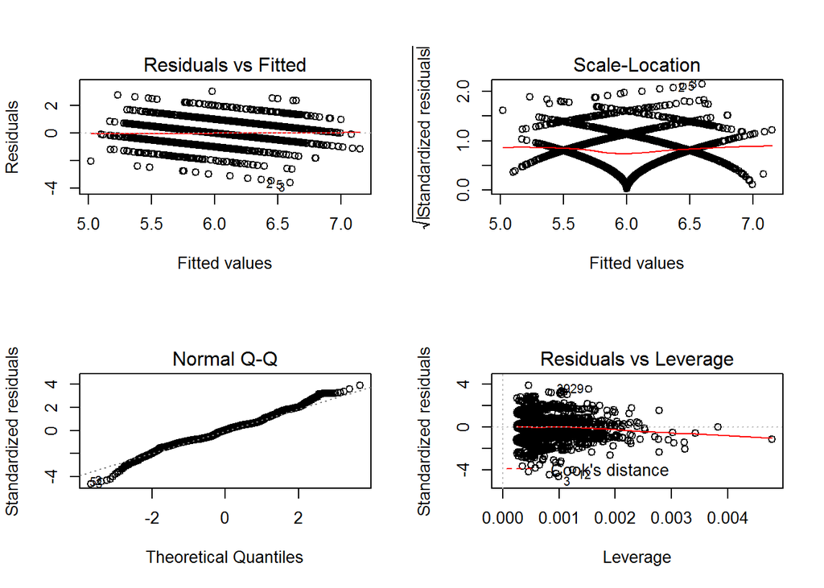

# Multivariate Analysis

## Talk about some of the relationships you observed in this part of the investigation. Were there features that strengthened each other in terms of looking at your feature(s) of interest?

Even though it appears that higher level of Alcohol brings higher Quality. However the study indicates that the alcohol level in wine stays at certain range for wines with high quality. That range is 11% to 13%. It appears that lower density brings higher quality. Since the density of a wine is mainly affected by Alcohol level and Residual Sugar. Higher Alcohol level brings down density and higher Residual sugar increases density. So low Residual Sugar also improves wine quality.This is verified by the study on Residual Sugar and Quality.

## Were there any interesting or surprising interactions between features?

When Total Acidity is about 7g/L, we have maximum number of wines with high Quality. And when Chlorides is about 0.025 g/L to 0.035g/L, we have the more wines with high Quality.

## OPTIONAL: Did you create any models with your dataset? Discuss the strengths and limitations of your model.

Yes, I created a linear model using the Quality of wines and the Alcohol and Residual Sugar of wines.

# Final Plots and Summary

## Plot One

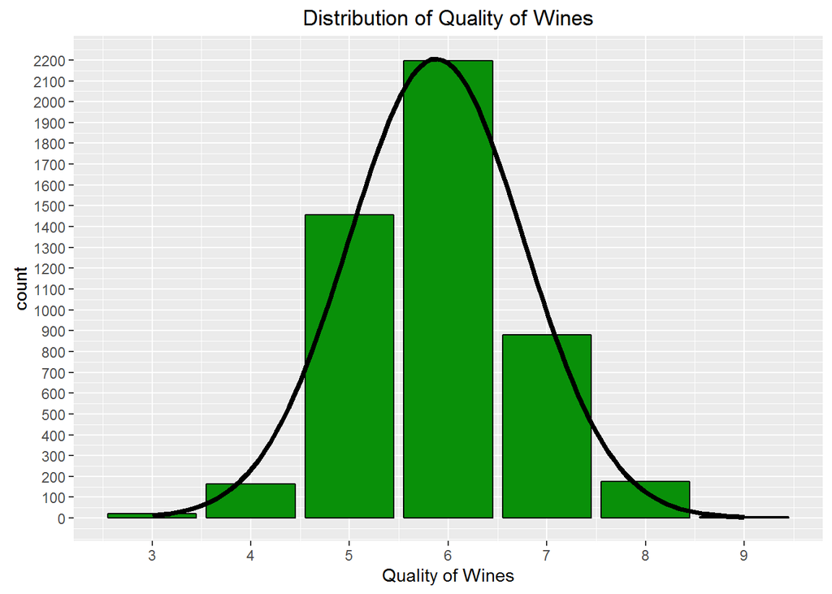

## Description One

Quality seems to be a normal distribution. Its statistics is below

```
##    Min. 1st Qu.  Median    Mean 3rd Qu.    Max.
##   3.000   5.000   6.000   5.878   6.000   9.000
```

Its standard deviation is below.

```
## [1] 0.8856386
```

## Plot Two

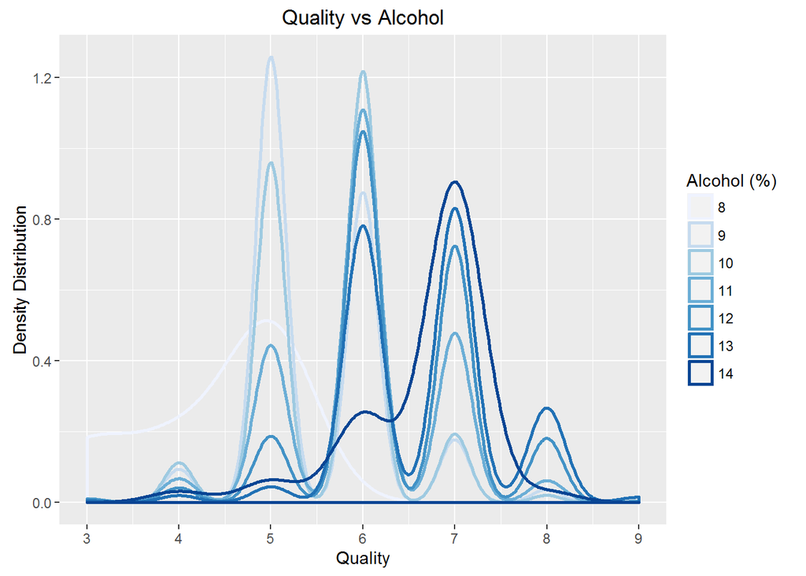

## Description Two

The study above shows that high Quality wines tend to have high Alcohol level. It seems that increasing the alcohol level in wines will make the wine to have high quality. However, by looking at it in details, we can see that Wine with Quality as 8 and 9 mostly have Alcohol level at 11%-13%. Alcohol at 14% only happens more in Wine with Quality as 7. So it appears that the alcohol level in wine stays at certain range (11%-13%) to have high quality.

## Plot Three

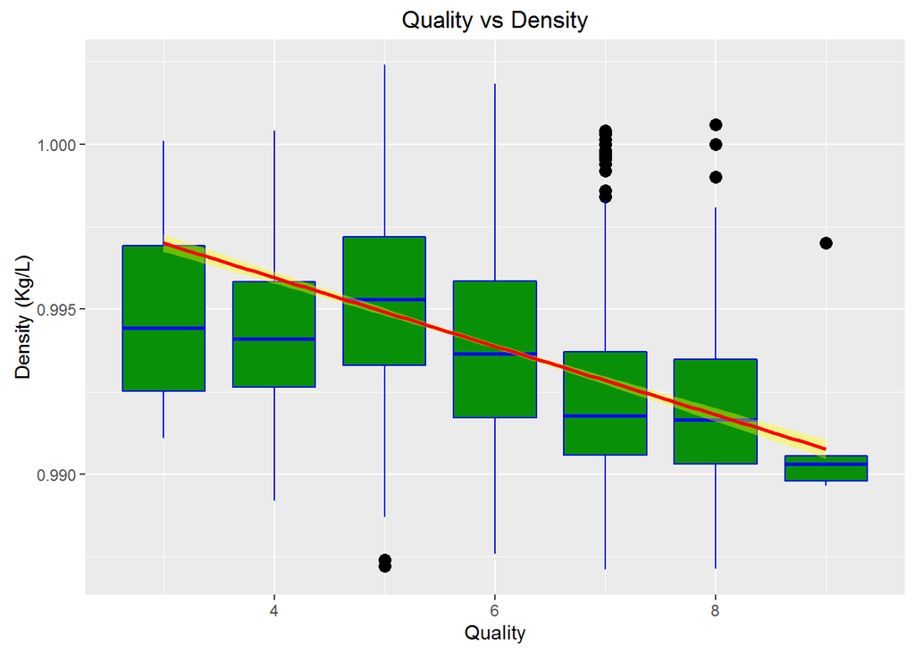

## Description Three

In this plot, the smoothing method “lm” is used. It clearly indicates that wines with higher Quality tends to have lower density. Density plays a very important role in the quality of wines. And it appears that lower the Density is, the better quality the wine has. The density of the wine is affected by Alcohol level. The density of alcohol is less than that of water. The more alcohol the wine has, the lower density the wine has. So the relation between Density and Quality is affected by the relation between Alcohol and Quality.

# Reflection

In my study, at first I plot the distribution of each variable in the dataset. And then I plot the relation between Quality and other variables and between some variables. At last, I plot how Quality is affected by two other variables together.

In the study of each variable, it is quite clear that they are kind of Normal Distribution except Residual Sugar, which is bimodal.

In the study of relationship between Quality and other variables, I find that Density, Alcohol and Residual Sugar have the clear relation with Quality. Other variables are not very clear. And some variables are depending on other variables, such as Total Sulfur Dioxide in fact contains Free Sulfur Dioxide. So I just ignore Free Sulfur Dioxide. I also create a new variable called Total Acidity which combines Fixed Acidity and Volatile Acidity.

The most difficult is the study of the effects of two different variables together on Quality. Such as Alcohol and Residual Sugar on Quality, Total Acidity and Chlorides on Quality, and Total Acidity and Residual Sugar on Quality. However I do not see any clear results.

Another thing to notice is that there exist outliers in all variables. These outliers bring down the accuracy of the study. For example, when I convert all these variables to categorical variables, it generates too many levels in each categorical variable.

What I want to answer but unable to answer in this study is still how two or more variables collectively affects Quality. The dataset does not differentiate the wines from different geographical areas and seasons. Neither does it differentiate the types of grapes. It also misses a lot of other variables such as Tartaric Acid and Tannin. Therefore, it does not produce the valid study result.

# Reference

- “White wine”" in www.wikipedia.org [link](http://en.wikipedia.org/wiki/White_wine)
- “Sweetness of wine” in www.wikipedia.org [link](https://en.wikipedia.org/wiki/Sweetness_of_wine)